# Working with annotations and labels in ggbrain

# Adding annotations

In addition to plotting categorical images, we often wish to annotate our plots with custom text in the margin or labels overlaid on certain areas. ggbrain provides the `annotate_slice` function, which allows you to add a custom annotation to one panel. This function attaches to `ggplot2::annotate` such that any of its settings apply to `annotate_slice` as well. Relative to typical annotations in ggplot2, with `ggbrain`, we must also provide x and y positions on the panel, as well the slice to which the annotation should be added.

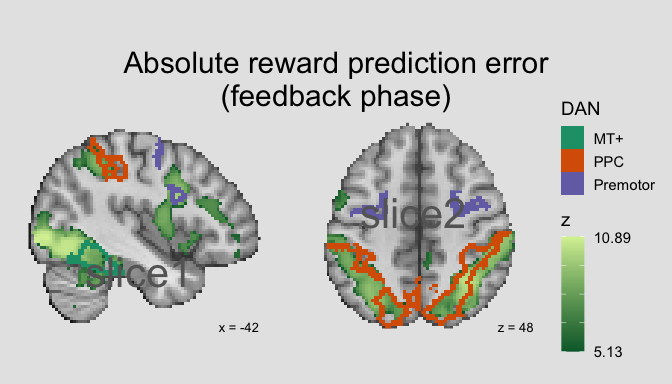

```r
ann <- abspe_gg +
  annotate_slice(x=20, y=20, slice_index=1, geom="text", label="slice1", color="gray40", size=11, hjust=0) +
  annotate_slice(x=20, y=40, slice_index=2, geom="text", label="slice2", color="gray40", size=11, hjust=0)

plot(ann)
```

If numbers are provided for the x and y positions, these specify that the annotation should be placed at those coordinates in the pixel/voxel matrix. This may not be especially intuitive since we often don’t think about things in the matrix (aka “ijk” space) of the NIfTI. Here, our NIfTIs have dimensions: 97, 115, 97.

Alternatively, we can use the shorthand of “left” and “right” for x coordinates and “top” and “bottom” for y coordinates. The shorthand of “middle” also works in x and y.

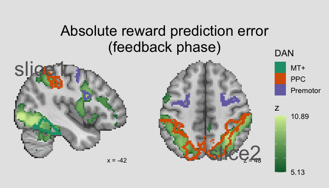

```r
ann <- abspe_gg +
  annotate_slice(x="left", y="top", slice_index=1, geom="text", label="slice1", color="gray40", size=11, hjust=0, vjust=1) +
  annotate_slice(x="right", y="bottom", slice_index=2, geom="text", label="slice2", color="gray40", size=11, hjust=1, vjust=0)

plot(ann)
```

Finally, we can use quantiles/percentiles along each axis to position things in relative space.

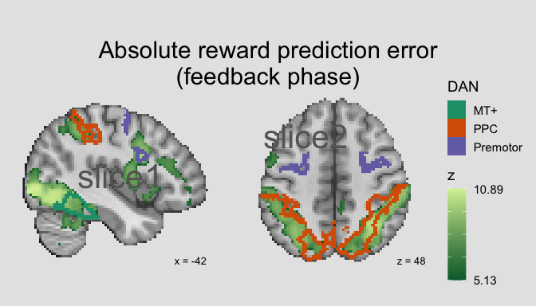

```r
ann <- abspe_gg +
  annotate_slice(x="q30", y="q60", slice_index=1, geom="text", label="slice1", color="gray40", size=11, hjust=0, vjust=1) +
  annotate_slice(x="q35", y="q70", slice_index=2, geom="text", label="slice2", color="gray40", size=11, hjust=0.5, vjust=0)

plot(ann)
```

As with `annotate` in ggplot2, the `annotate_slice` function can also be used to add other geometric shapes such as rectangles or points. For example, we could highlight the occipital region here.

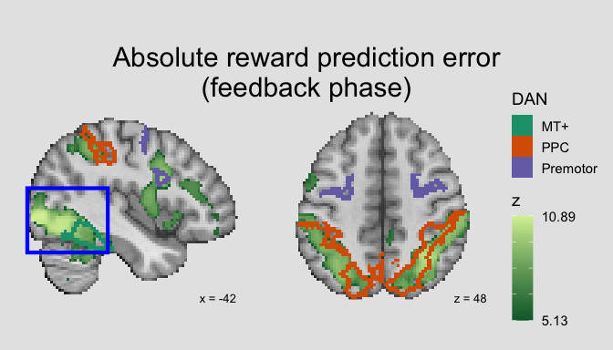

```r
ann <- abspe_gg +
  annotate_slice(xmin="q0", xmax="q38", ymin="q25", ymax="q59", slice_index=1, geom="rect",
                 color="blue", fill="transparent", linewidth=1.5)
plot(ann)
```

# Adding labels systematically

Finally, we may wish to label points more systematically based on a labeling `data.frame`, akin to how `geom_text` can be used to label many points.

For example, we may want to add region labels to several regions on the plot. To do this, `ggbrain` provides `geom_region_text`, `geom_region_text_repel`, `geom_region_label`, and `geom_region_label_repel`.

The `text` versus `label` distinction matches ggplot2, such that “label” annotations have a rectangle behind them while “text” annotations do not.

The `repel` versions of these functions rely on [`ggrepel`](https://CRAN.R-project.org/package=ggrepel), a useful package for pushing labels away from their specified coordinates to avoid overplotting of labels and covering of relevant data points.

Extending our plot above, perhaps we might like to label the Schaefer parcellation regions comprising the three DAN areas of MT+, PPC, and Premotor. These labels already exist in our `schaefer200_atlas_labels` data.frame. Let’s use the MNI_Glasser_HCP_v1.0 labels.

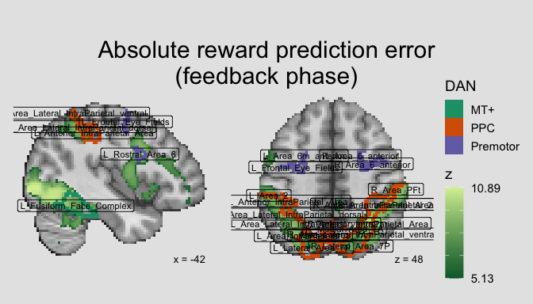

```r
ann <- abspe_gg +
  geom_region_label(image="atlas", label_column="MNI_Glasser_HCP_v1.0", size=3, color="black")
#
#   geom_region_label_repel(image = "dan_clust", label_column = "value", min.segment.length = 0, size=3,
#                           color="black", force_pull=0, force=1.5, max.overlaps=Inf, box.padding = 0.5, label.padding=0.15, min_px = 20) +

plot(ann)
```

That’s clearly too busy! And those region labels are pretty long. We might instead use the automated labels alongside domain knowledge to create custom labels that are both potentially more accurate and also easier to read. Here, I’ve labeled a few of the regions in the DAN by looking at relevant literature and comparing it against anatomical labels. Although these labels are imperfect, they are more useful for visualization than the long labels.

[output not shown]

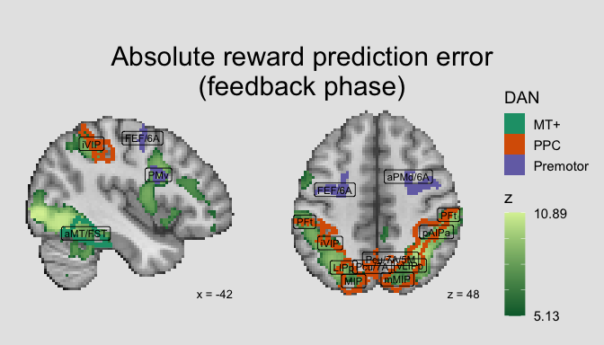

```r
ann <- abspe_gg +
  geom_region_label(image="atlas", label_column="custom_label", size=3, color="black")
#
#   geom_region_label_repel(image = "dan_clust", label_column = "value", min.segment.length = 0, size=3,
#                           color="black", force_pull=0, force=1.5, max.overlaps=Inf, box.padding = 0.5, label.padding=0.15, min_px = 20) +

plot(ann)
```